# Using the BCDA toolset

Mikhail Popov

2016-04-08

|  | No Attack | Myocardial Infraction | Sum |
| --- | --- | --- | --- |
| Aspirin | 10933 | 104 | 11037 |
| Placebo | 10845 | 189 | 11034 |
| Sum | 21778 | 293 | 22071 |

## Frequentist Approach

Using the frequentist approach, the individual cell probabilities $\pi_{ij}$ are estimated via $p_{ij} = n_{ij}/n_{++}$:

|  | No Attack | Myocardial Infraction | Sum |
| --- | --- | --- | --- |
| Aspirin | 0.495 | 0.005 | 0.5 |
| Placebo | 0.491 | 0.009 | 0.5 |
| Sum | 0.987 | 0.013 | 1.0 |

```r
stats::chisq.test(aspirin) # usually done for large sample tables
```

```
##
##  Pearson's Chi-squared test with Yates' continuity correction
##
## data:  aspirin
## X-squared = 24, df = 1, p-value = 8e-07
```

```r
stats::fisher.test(aspirin) # usually done for small sample tables
```

```
##
##  Fisher's Exact Test for Count Data
##
## data:  aspirin
## p-value = 5e-07
## alternative hypothesis: true odds ratio is not equal to 1
## 95 percent confidence interval:
##  1.432 2.354
## sample estimates:
## odds ratio
##      1.832
```

The two major problems with the frequentist approach are:

1. The rarity of the disease.
2. The large sample size yields a tiny p-value for a small effect, so we call it *highly statistically significant*.

As Andrew Gelman [said](http://andrewgelman.com/2009/06/18/the_sample_size/), “In general: small n, unlikely to get small p-values. Large n, likely to find something. Huge n, almost certain to find lots of small p-values.”

Alternatively, we can abandon null hypothesis signifiance test (NHST) approach that yields a p-value and instead employ Bayesian methods (which have their own quirks).

## Bayesian Approach

In Bayesian statistics, we are concerned with the posterior distribution of the parameter(s) of interest $\theta$ given the data. Using Bayes Theorem, we can express the posterior distribution $p(\theta~|~\text{data})$ as proportional to the product of the likelihood $p(\text{data}~|~\theta)$ and the prior $p(\theta)$:
$$p(\theta~|~\text{data}) \propto p(\text{data}~|~\theta)~p(\theta).$$

In essence, while the classical (frequentist) approach regards $\theta$ as a fixed entity whose value is to be estimated, Bayesian perspective views $\theta$ as a random variable whose posterior probability distribution is to be estimated.

```r
library(BCDA)
```

We can use the `est_multinom` function to estimate the multinomial cell probabilities ($\pi_{11}, \pi_{12}, \pi_{21}, \pi_{22}$) using methods developed by Fienberg and Holland (1973). When we don’t provide hyperparameters $\gamma_{ij}$, they are calculated using a simple model ($\gamma_{ij} = p_{i+}p_{+j}$).

```r
est_multinom(aspirin)
```

|  | No Attack | Myocardial Infraction | Sum |
| --- | --- | --- | --- |
| Aspirin | 0.495 | 0.005 | 0.5 |
| Placebo | 0.491 | 0.009 | 0.5 |
| Sum | 0.987 | 0.013 | 1.0 |

We can also employ the knowledge that we do have about the prevalence of heart attacks in U.S. via the [American Heart Association](https://www.heart.org/idc/groups/heart-public/@wcm/@sop/@smd/documents/downloadable/ucm_449846.pdf).

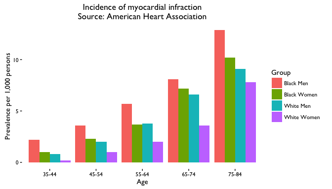

The prevalence (averaged across age, sex, and race) is 0.469%, which we can use as very naive prior information in our model.

| No Attack | Avg Prevalence of M.I. |
| --- | --- |
| 0.995 | 0.005 |

|  | No Attack | Avg Prevalence of M.I. |
| --- | --- | --- |
| Aspirin | 0.498 | 0.002 |
| Placebo | 0.498 | 0.002 |

```r
est_multinom(aspirin, prior = prior)
```

|  | No Attack | Myocardial Infraction | Sum |
| --- | --- | --- | --- |
| Aspirin | 0.496 | 0.004 | 0.5 |
| Placebo | 0.493 | 0.007 | 0.5 |
| Sum | 0.989 | 0.011 | 1.0 |

### Tests of Independence

As before, we have a null hypothesis that outcome is independent of group. This time, we are going to use the Bayes factor (computed with the **LearnBayes** package) and interpret it using Kass and Raftery’s (1995) suggestion.

```r
bf <- LearnBayes::ctable(aspirin, matrix(rep(1, 4), 2)) # 1793
BCDA:::interpret_bf(bf)
```

```
## [1] "Very strong evidence against H0."
```

```r
test_independence(aspirin)
```

[output not shown]

Another way to do this is to fit a log-linear model to the counts and look at the interaction. This requires the **conting** package.

```r
library(conting) # for summary.bcct()
set.seed(0)
fit <- log_linear(aspirin, c('drug', 'attack'))
summary(fit) # from the 'conting' package
```

```
## Posterior summary statistics of log-linear parameters:
##               post_prob post_mean post_var lower_lim upper_lim
## (Intercept)           1     7.118 0.000898    7.0614    7.1809
## drug1                 1    -0.147 0.000890   -0.2114   -0.0942
## attack1               1     2.177 0.000909    2.1064    2.2299
## drug1:attack1         1     0.151 0.000885    0.0988    0.2160
## NB: lower_lim and upper_lim refer to the lower and upper values of the
## 95 % highest posterior density intervals, respectively
##
## Posterior model probabilities:
##   prob model_formula
## 1 1    ~drug + attack + drug:attack
##
## Total number of models visited =  1
##
## Under the X2 statistic
##
## Summary statistics for T_pred
##    Min. 1st Qu.  Median    Mean 3rd Qu.    Max.
##   0.019   1.870   3.360   3.970   5.400  19.600
##
## Summary statistics for T_obs
##    Min. 1st Qu.  Median    Mean 3rd Qu.    Max.
##   0.002   1.810   3.440   3.960   5.410  17.600
##
## Bayesian p-value =  0.505
```

Under the $\chi^2$ discrepancy statistic, the Bayesian p-value of 0.51 does not indicate an inadequate model meaning that predictions of the cell counts are consistent with the observed cell counts.

### Strength and Direction of Association

We assume an independent Binomial model with independent Beta priors on the probability parameter. For each group $i = 1, 2$ (aspirin and placebo):
$$X_i \sim \text{Binom}(N_i, \pi_i),~\text{and}\\ \pi_i \sim \text{Beta}(\alpha_i, \beta_i).$$

However, we still need to provide the $\alpha$ and $\beta$ hyperparameters. We can set them to $\alpha=\beta=1$ which corresponds to a non-informative prior on $\pi$, or we can specify them such that the shape of the Beta prior better reflects our knowledge about the probability of (not) having a heart attack while being non-informative with respect to the groups. After all, we **don’t** know which group has a better outcome, but if we did, we could specify the parameters to reflect that knowledge.

```r
set.seed(0)
fit <- beta_binom(aspirin)
```

We can also provide success counts and totals: `fit <- beta_binom(x = aspirin[, 1], n = aspirin[, 1] + aspirin[, 2])`

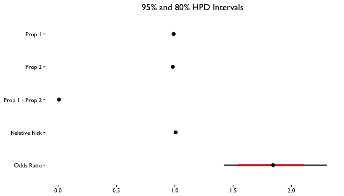

```r
plot(fit, interval_type = "HPD") # requires coda package to be installed
```

```r
# plot(fit) will use credible intervals computed using the quantile method
```

```r
summary(fit, interval_type = "HPD") # requires coda package to be installed
# summary(fit) will give credible intervals using the quantile method
```

|  | estimate | std.error | conf.low | conf.high |
| --- | --- | --- | --- | --- |
| p1 | 0.9905 | 0.0009 | 0.9887 | 0.9923 |
| p2 | 0.9828 | 0.0012 | 0.9803 | 0.9851 |
| prop_diff | 0.0077 | 0.0015 | 0.0048 | 0.0109 |
| relative_risk | 1.0078 | 0.0016 | 1.0049 | 1.0111 |
| odds_ratio | 1.8423 | 0.2257 | 1.4202 | 2.3031 |

## Updating

```r
set.seed(0)
group_1 <- sample.int(2, 20, prob = c(0.55, 0.45), replace = TRUE)-1
group_2 <- sample.int(2, 20, prob = c(0.65, 0.35), replace = TRUE)-1
fit <- beta_binom(c(sum(group_1), sum(group_2)), c(length(group_1), length(group_2)))
temp <- summary(fit); temp$term <- rownames(temp); rownames(temp) <- NULL; temp$day <- 1
posterior_summaries <- temp
```

```r
for (day in 2:14) {
  group_1 <- sample.int(2, 10, prob = c(0.55, 0.45), replace = TRUE)-1
  group_2 <- sample.int(2, 10, prob = c(0.65, 0.35), replace = TRUE)-1
  fit <- update(fit, c(sum(group_1), sum(group_2)), c(length(group_1), length(group_2)))
  temp <- summary(fit); temp$term <- rownames(temp); rownames(temp) <- NULL; temp$day <- day
  posterior_summaries <- rbind(posterior_summaries, temp)
}
posterior_summaries$term <- factor(posterior_summaries$term,
                                   levels = c("p1", "p2", "prop_diff",
                                              "relative_risk", "odds_ratio"),
                                   labels = c("Prop 1", "Prop 2", "Prop 1 - Prop 2",
                                              "Relative Risk", "Odds Ratio"))
```

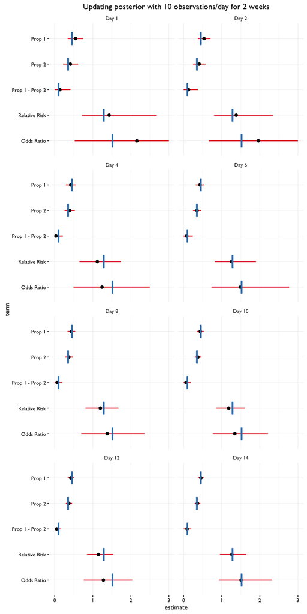

## References

Physician’s Health Study. (1988). *New England Journal of Medicine*, **318**, 262-264.

Agresti, A. (2013). Categorical Data Analysis. John Wiley & Sons.

Agresti, A., & Hitchcock, D. B. (2005). Bayesian inference for categorical data analysis. Statistical Methods and Applications.

Fienberg, S. E., & Holland, P. W. (1973). Simultaneous estimation of multinomial cell probabilities. Journal of the American Statistical Association.

Kass, R. E., & Raftery, A. E. (1995). Bayes factors. Journal of the American Statistical Association.